title: “Índice de Distribuição Regional do Gasto Público (IDRGP)” subtitle: “Análise do Ciclo PPA 2022–2025” author: “SEPLAN/SIME/CPMA — Prefeitura de São Paulo, 2026.” date: “13/05/2026” output: html_document: toc: true toc_float: true theme: flatly code_folding: show highlight: tango number_sections: true —

# 1. Introdução

O **IDRGP** (Índice de Distribuição Regional do Gasto Público) mede se a distribuição territorial dos gastos públicos municipais está alinhada às prioridades sociais e de infraestrutura de cada subprefeitura. Esse monitoramento se dá a partir da diferença entre os dados da Execução Regionalizada do Orçamento e da Alocação Orçamentária Esperada, expressa a partir do **Índice de Vulnerabilidade Urbana (IVU - 2025)** atualizado por SEPLAN/CPMA.

Este documento consolida a análise do ciclo PPA **2022–2025**, considerando **todo o universo** de projetos/atividades e funções, sem seleção.

**Fontes de dados:**

- Dados regionalizados da execução orçamentária — Secretaria de Fazenda
- AOE ou IDRGP Alvo — SGM/SEPLAN/CPMA (IVU - 2025)
- Dados cartográficos — GeoSampa (Subprefeituras de São Paulo)

**Referência:** https://prefeitura.sp.gov.br/web/planejamento/w/execucao_orcamentaria

## 2. Bibliotecas convocadas

Este bloco reúne os pacotes necessários para o funcionamento do modelo analítico. Em termos práticos, ele estrutura três capacidades centrais do estudo: (i) tratamento e organização de grandes bases de dados orçamentários, (ii) integração com dados territoriais (mapas das subprefeituras) e (iii) produção de visualizações e tabelas para apoio à decisão. A presença de bibliotecas específicas para leitura de Excel, manipulação de dados e geoprocessamento garante que o fluxo seja reproduzível e passível de atualização com novas bases.

## 3. Funções auxiliares

Este trecho resolve um problema recorrente na administração pública: a inconsistência na escrita de nomes entre diferentes bases. A função cria uma “chave única” ao remover acentos, padronizar letras e eliminar variações textuais. Na prática, isso permite cruzar corretamente dados de orçamento, indicadores sociais e mapas, evitando erros de correspondência entre subprefeituras. É um elemento crítico para a confiabilidade da análise.

```
## ✅ norm_name(): todos os 12 casos de teste passaram.
```

## 4. Tabela de referência das subprefeituras

Aqui é estabelecida a base oficial de correspondência entre siglas e nomes das 32 subprefeituras. Essa tabela funciona como padrão institucional de nomenclatura, garantindo que todas as bases utilizem a mesma referência territorial.

Ela é essencial para consolidar informações oriundas de diferentes sistemas administrativos e assegurar consistência na leitura dos resultados.

## 5.Definição dos caminhos dos arquivos

Este bloco organiza o acesso às bases de dados utilizadas na análise. Ele define onde estão armazenados os arquivos e automatiza sua localização, permitindo que o sistema funcione mesmo quando há pequenas variações nos nomes dos arquivos.

Além disso, incorpora mecanismos de verificação: caso algum arquivo essencial esteja ausente, o processo é interrompido com aviso claro. Isso evita análises incompletas ou inconsistentes e reforça o controle de qualidade dos dados.

```
## 📁 Pasta de dados: C:/Users/d954257/OneDrive - rede.sp/Área de Trabalho/IDRGP/IDRGP-2025/R Markdown/dados
```

# 6. Importação do IVU com AOE ou IDRGP Alvo

Neste ponto, o modelo incorpora o parâmetro normativo da análise: o IDRGP Alvo, derivado do Índice de Vulnerabilidade Urbana.

O código transforma o IVU em uma distribuição proporcional (que soma 100%), indicando quanto cada subprefeitura deveria receber em termos de gasto público, dado seu nível relativo de vulnerabilidade.

Essa etapa estabelece a referência contra a qual a execução orçamentária será avaliada.

## 7. Verificação da qualidade das informações

Este bloco realiza uma checagem fundamental: confirma se o índice calculado está consistente (ou seja, se a soma total equivale a 100%) e se todas as subprefeituras estão presentes.

Também prepara a base para integração com outras informações, criando a chave padronizada. Trata-se de uma etapa de validação que assegura que os resultados posteriores sejam estatisticamente e operacionalmente confiáveis.

```
## IDRGP Alvo verificado: soma = 1
```

```
## Subprefeituras no IDRGP: 32 (esperado: 32)
```

| Subprefeitura | IDRGP Alvo |
| --- | --- |
| Capela do Socorro | 0,0823 |
| M’Boi Mirim | 0,0768 |
| Campo Limpo | 0,0705 |
| São Mateus | 0,0578 |
| Cidade Ademar | 0,0543 |
| Itaquera | 0,0498 |
| Freguesia-Brasilândia | 0,0449 |
| Parelheiros | 0,0419 |
| São Miguel Paulista | 0,0400 |
| Jaçanã-Tremembé | 0,0362 |
| Pirituba-Jaraguá | 0,0355 |
| Itaim Paulista | 0,0344 |
| Penha | 0,0333 |
| Butantã | 0,0314 |
| Guaianases | 0,0311 |
| Sapopemba | 0,0285 |
| Ipiranga | 0,0285 |
| Cidade Tiradentes | 0,0248 |
| Casa Verde-Cachoeirinha | 0,0229 |
| Perus/Anhanguera | 0,0213 |
| Sé | 0,0177 |
| Ermelino Matarazzo | 0,0156 |
| Mooca | 0,0152 |
| Vila Maria-Vila Guilherme | 0,0147 |
| Vila Prudente | 0,0147 |
| Jabaquara | 0,0146 |
| Santana-Tucuruvi | 0,0144 |
| Aricanduva-Formosa-Carrão | 0,0128 |
| Lapa | 0,0120 |
| Vila Mariana | 0,0079 |
| Santo Amaro | 0,0078 |
| Pinheiros | 0,0063 |

# 8. Importação e consolidação das bases orçamentárias

Aqui ocorre a construção da base principal da análise. Os dados de execução orçamentária dos quatro anos do PPA são carregados, padronizados e consolidados em uma única estrutura.

O código garante que apenas as colunas comuns entre os anos sejam utilizadas, permitindo comparabilidade ao longo do tempo.

O resultado é uma base integrada que representa todo o gasto público municipal regionalizado no período 2022–2025

```
## Colunas comuns aos 4 anos: 27
```

```
## # A tibble: 328 × 9
## # Groups:   CÓDIGO_PROJ_ATIV [88]
##    CÓDIGO_PROJ_ATIV DESCRIÇÃO_PROJ_ATIV   ANO_EMPENHO TIPO_REGIONALIZAÇÃO  valor
##    <chr>            <chr>                       <dbl> <chr>                <dbl>
##  1 4701             Compensações Tarifár…        2022 Despesa Não-Region… 5.05e9
##  2 4701             Compensações Tarifár…        2023 Despesa Não-Region… 5.30e9
##  3 4701             Compensações Tarifár…        2024 Despesa Regionaliz… 4.24e9
##  4 4701             Compensações Tarifár…        2025 Despesa Regionaliz… 7.12e9
##  5 4113             Sistema Municipal de…        2022 Despesa Não-Region… 1.02e9
##  6 4113             Sistema Municipal de…        2023 Despesa Regionaliz… 6.32e8
##  7 4113             Sistema Municipal de…        2024 Despesa Regionaliz… 1.45e9
##  8 4113             Sistema Municipal de…        2025 Despesa Regionaliz… 1.71e9
##  9 6553             Alimentação Escolar          2022 Despesa Não-Region… 7.29e8
## 10 6553             Alimentação Escolar          2023 Despesa Não-Region… 1.18e9
## # ℹ 318 more rows
## # ℹ 4 more variables: total <dbl>, percentual <dbl>, total_quad <dbl>,
## #   mudou <lgl>
```

Resumo dos Projetos/Atividades

| Indicador | Valor |
| --- | --- |
| Total de Projetos/Atividades | 490 |
| Projetos/Atividades Regionalizáveis | 360 |
| Projetos/Atividades com Mudança | 88 |

```
## # A tibble: 400 × 8
## # Groups:   CÓDIGO_PROJ_ATIV, TIPO_REGIONALIZAÇÃO [119]
##    CÓDIGO_PROJ_ATIV DESCRIÇÃO_PROJ_ATIV   ANO_EMPENHO TIPO_REGIONALIZAÇÃO  valor
##    <chr>            <chr>                       <dbl> <chr>                <dbl>
##  1 1055             Ampliação, Reforma e…        2022 Despesa Regionaliz… 1.42e6
##  2 1055             Ampliação, Reforma e…        2022 <NA>                0
##  3 1055             Ampliação, Reforma e…        2023 Despesa Regionaliz… 6.37e6
##  4 1055             Ampliação, Reforma e…        2023 <NA>                0
##  5 1055             Ampliação, Reforma e…        2024 Despesa Regionaliz… 2.52e6
##  6 1055             Ampliação, Reforma e…        2024 <NA>                7.49e5
##  7 1055             Ampliação, Reforma e…        2025 Despesa Regionaliz… 2.55e6
##  8 1055             Ampliação, Reforma e…        2025 <NA>                0
##  9 1095             Construção de Termin…        2022 Despesa Regionaliz… 2.34e5
## 10 1095             Implantação e Constr…        2023 Despesa Regionaliz… 1.01e8
## # ℹ 390 more rows
## # ℹ 3 more variables: total <dbl>, percentual <dbl>, variacao <dbl>
```

```
## # A tibble: 10 × 6
## # Groups:   CÓDIGO_PROJ_ATIV, TIPO_REGIONALIZAÇÃO [3]
##    CÓDIGO_PROJ_ATIV ANO_EMPENHO TIPO_REGIONALIZAÇÃO      valor  total percentual
##    <chr>                  <dbl> <chr>                    <dbl>  <dbl>      <dbl>
##  1 2096                    2022 Despesa Regionalizável  7.46e7 2.06e8       0.36
##  2 2096                    2023 Despesa Regionalizável  1.42e8 1.42e8       1
##  3 2096                    2024 Despesa Regionalizável  1.43e8 1.43e8       1
##  4 2096                    2025 Despesa Regionalizável  1.24e8 1.24e8       1
##  5 4113                    2022 Despesa Não-Regionaliz… 1.02e9 1.02e9       1
##  6 4113                    2023 Despesa Não-Regionaliz… 4.67e8 1.10e9       0.42
##  7 4113                    2023 Despesa Regionalizável  6.32e8 1.10e9       0.58
##  8 4113                    2024 Despesa Não-Regionaliz… 1.13e8 1.58e9       0.07
##  9 4113                    2024 Despesa Regionalizável  1.45e9 1.58e9       0.92
## 10 4113                    2025 Despesa Regionalizável  1.71e9 1.71e9       1
```

## 9. Análise da regionalização das ações orçamentárias

Este bloco examina como o orçamento está distribuído territorialmente dentro de cada ação governamental.

Ele identifica:

- o grau de regionalização de cada ação;
- mudanças ao longo do tempo;
- inconsistências na classificação.

Do ponto de vista da gestão, essa etapa permite entender se as políticas públicas estão sendo territorializadas de forma consistente ou se ainda operam de maneira centralizada (“supra”).

A despeito de haver muitos casos NA em 2024, a tabela mostra que não há uma variação tão grande entre os casos regionalizados e não regionalizados na maioria das ações.

Alguns destaques em relação a inconsistência (variação) podem ser:

### Sucesso de regionalização:

- *4701-Compensações Tarifárias do Sistema de Ônibus*, passa a ser regionalizada em 2024. Este é o caso de “inconsistência” (variação) que envolve maior montante de recursos.
- *4113-Sistema Municipal de Regulação, Controle, Avaliação e Auditoria do SUS* não foi regionalizada em 2022, mas avançou *paulatinamente* até ser 100% regionalizada em 2025.
- *6553-Alimentação Escolar*, foi regionalizada só em 2025.
- As três anteriore, são os proj/ativ com mais recursos liquidados, depois vem *6007-Serviços de Limpeza Urbana - Varrição e Lavagem de Áreas Públicas* e *6010-Concessão dos Serviços Divisíveis de Limpeza Urbana em Regime Público*, que passaram a ser totalmente regionalizadas a partir de 2023.
- *2096-Manutenção e Operação de Terminais de Ônibus* era pouco regionalizada em 2022, mas depois foi para 100%.
- Outros casos de ampliação da regionalização do dado ao longo dos anos: *2512-Manutenção e Operação de Serviço de Atendimento Médico de Urgência (SAMU)*, *2635-Serviço de Moradia Transitória* e *6669-Educação Ambiental*.
- *7127-Estudos, Planos e Projetos Ambientais* é um caso que aumenta a regionalização, mas não chega a 100%.

#### Casos de “desregionalização”:

- *1055-Ampliação, Reforma e Requalificação das Instalações para a Guarda Civil Metropolitana* teva uma desregionalização em 2024.
- *4901-Manutenção e Operação dos Sistemas de Monitoramento e Alerta de Enchentes* também.
- *5507-Projeto de Intervenção Urbana - PIU* ficou menos regionalizada de uma ano para o outro e tem a proporção 60x40.

#### Casos bem dividido:

- A ação *4910-Fomento à Cooperação, Parcerias e Captação de Investimentos Internacionais* tem uma proporção baixa de regionálizável, variando entre 12$ e 28% a depender do ano.
- *4332-Manutenção da Ouvidoria de Direitos Humanos*
- *7208-Parceria Público-Privada (PPP) - CEU*

## 10. Função de limpeza unificada

Este é um dos núcleos operacionais do modelo. A função:

- padroniza os dados;
- remove inconsistências (NA//);
- elimina registros não territorializáveis;
- organiza as variáveis essenciais.

O resultado é uma base limpa e homogênea, pronta para análise.

Para a gestão, isso significa que os dados utilizados já passaram por um processo rigoroso de qualificação.

## 11. Processamento Populacional e dos 4 anos

Este bloco consolida a base demográfica histórica e prepara as bases orçamentárias para o ciclo do PPA.

## 12. Funções de suporte e regionalização

```
## ✅ Ano 2022 : 254068 linhas, 32 subprefeituras, R$ 16.129.553.626
```

```
## ✅ Ano 2023 : 300801 linhas, 32 subprefeituras, R$ 33.321.223.743
## ✅ Ano 2024 : 354540 linhas, 32 subprefeituras, R$ 45.647.361.712
## ✅ Ano 2025 : 441358 linhas, 32 subprefeituras, R$ 57.170.300.140
```

```
## <environment: R_GlobalEnv>
```

```
## <environment: R_GlobalEnv>
```

```
## ✅ Os 4 anos possuem valores totais DISTINTOS — dados carregados corretamente.
```

Resumo das bases orçamentárias processadas

| Ano | Linhas | Subprefeituras | Valor Total |
| --- | --- | --- | --- |
| 2022 | 254068 | 32 | R$ 16.129.553.626 |
| 2023 | 300801 | 32 | R$ 33.321.223.743 |
| 2024 | 354540 | 32 | R$ 45.647.361.712 |
| 2025 | 441358 | 32 | R$ 57.170.300.140 |

## 12. Base cartográfica (uma vez só)

Este bloco conecta os dados financeiros ao território, incorporando o shapefile das subprefeituras.

A partir disso, cada valor orçamentário passa a estar associado a uma unidade espacial, viabilizando a produção de mapas e análises territoriais.

É aqui que o orçamento correlaciona-se ao território.

# 13. Funções de cálculo do IDRGP

Este conjunto de funções realiza o cálculo central do estudo: compara o gasto real com o gasto esperado (IDRGP Alvo).

Também aplica testes estatísticos para avaliar se as diferenças observadas são significativas.

Além disso, classifica cada subprefeitura em três situações:

acima do esperado, dentro do esperado, abaixo do esperado.

Essa etapa traduz os dados complexos orçamentários em um diagnóstico direto para a tomada de decisão.

### 14. Preparação das análises por ano

Neste bloco, o modelo executa automaticamente todas as análises para cada ano do ciclo.

Ele organiza os resultados em estruturas padronizadas, permitindo:

comparações entre anos; geração de tabelas; produção de relatórios.

É o momento em que o processamento técnico se transforma em insumo.

## 15. Resumo da regionalização

Aqui é apresentado um indicador sintético: o percentual do orçamento efetivamente regionalizado em cada ano.

Esse dado permite avaliar a evolução da capacidade do município de territorializar suas políticas públicas ao longo do tempo.

Regionalização do orçamento (por valor) — resumo por ano

| Ano | Valor total | Valor regionalizado | % regionalizado |
| --- | --- | --- | --- |
| 2022 | R$ 74.233.972.013 | R$ 16.129.553.626 | 21.7% |
| 2023 | R$ 91.190.652.546 | R$ 33.321.223.743 | 36.5% |
| 2024 | R$ 94.485.897.645 | R$ 45.647.361.712 | 48.3% |
| 2025 | R$ 103.136.618.407 | R$ 57.170.300.140 | 55.4% |

### 16. Rotina de análise anual (imprimir_analise_ano)

Este bloco organiza a apresentação dos resultados para cada ano. Ele:

resume a regionalização; destaca as ações mais territorializadas; apresenta os resultados estatísticos do IDRGP; classifica as subprefeituras.

Além disso, exporta os dados para Excel, facilitando o uso por equipes técnicas e gestores.

## 16.1. Análise de 2022

### Ações regionalizadas (projeto/atividade)

Tabela completa exportada em: `resultados/regionalizacao_acoes_2022.xlsx`

Resumo da regionalização por ação — 2022

| N ações | Valor total | Valor regionalizado | % regionalizado |
| --- | --- | --- | --- |
| 405 | R$ 74.233.972.013 | R$ 16.129.553.626 | 21.7% |

Top 15 ações com MAIOR regionalização (por valor) — 2022

| Projeto/atividade | Valor total | % regionalizado | N subpref (regionalizado) |
| --- | --- | --- | --- |
| Manutenção e Operação da Rede Parceira - Centro de Educação Infantil (CEI) | R$ 4.553.913.339 | 100.0% | 31 |
| Manutenção e Operação de Equipamentos de Proteção Social Especial à População em Situação de Rua | R$ 497.830.795 | 100.0% | 32 |
| Manutenção e Operação de Equipamentos de Convivência e Fortalecimento de Vínculos para Crianças e Adolescentes | R$ 362.749.440 | 100.0% | 32 |
| Manutenção e Operação de Unidades Educacionais - Escola Municipal de Ensino Fundamental (EMEF) | R$ 320.002.939 | 100.0% | 32 |
| Manutenção de Sistemas de Drenagem | R$ 296.225.531 | 100.0% | 32 |
| Construção e Implantação de Centros Educacionais Unificados (CEU) | R$ 289.379.725 | 100.0% | 9 |
| Manutenção e Operação de Centros Educacionais Unificados (CEU) | R$ 267.551.162 | 100.0% | 32 |
| Transferência de Recursos Financeiros para as Unidades Educacionais - Educação Infantil | R$ 236.665.367 | 100.0% | 26 |
| Manutenção e Operação de Áreas Verdes e Vegetação Arbórea | R$ 235.088.324 | 100.0% | 32 |
| Transferência de Recursos Financeiros para as Unidades Educacionais - Ensino Fundamental | R$ 234.121.719 | 100.0% | 26 |
| Manutenção e Operação de Equipamentos de Proteção Social Especial a Crianças, Adolescentes e Jovens em Risco Social | R$ 226.598.778 | 100.0% | 32 |
| Manutenção e Operação de Escolas Municipais de Educação Infantil (EMEI) | R$ 206.265.630 | 100.0% | 32 |
| Manutenção e Operação no Serviço de Guias e Sarjetas (Vias e Logradouros) | R$ 146.188.754 | 100.0% | 32 |
| Manutenção e Operação do Controle e Fiscalização de Tráfego | R$ 142.974.106 | 100.0% | 2 |
| Manutenção e Operação de Centros de Educação Infantil (CEI) | R$ 141.415.242 | 100.0% | 32 |

### IDRGP e testes estatísticos

- Total do ano: R$ 16.129.553.626
- KS (normalidade): D = 0,2886 | p = 7,470e-03
- Método: WILCOXON | p = 3,64e-01
- IC 95% (diferença real - alvo): [-0,007637; 0,002402]

Classificação estatística (IC 95%) — 2022

| Status (IC 95%) | N subprefeituras |
| --- | --- |
| Abaixo do IDRGP Alvo | 10 |
| Dentro do IDRGP Alvo | 9 |
| Acima do IDRGP Alvo | 13 |

## 16.2. Análise de 2023

### Ações regionalizadas (projeto/atividade)

Tabela completa exportada em: `resultados/regionalizacao_acoes_2023.xlsx`

Resumo da regionalização por ação — 2023

| N ações | Valor total | Valor regionalizado | % regionalizado |
| --- | --- | --- | --- |
| 404 | R$ 91.190.652.546 | R$ 33.321.223.743 | 36.5% |

Top 15 ações com MAIOR regionalização (por valor) — 2023

| Projeto/atividade | Valor total | % regionalizado | N subpref (regionalizado) |
| --- | --- | --- | --- |
| Manutenção e Operação da Rede Parceira - Centro de Educação Infantil (CEI) | R$ 4.502.867.968 | 100.0% | 31 |
| Pavimentação e Recapeamento de Vias | R$ 3.295.660.300 | 100.0% | 32 |
| Intervenções no Sistema de Drenagem | R$ 1.406.534.523 | 100.0% | 30 |
| Programa Pode Entrar | R$ 1.248.287.708 | 100.0% | 15 |
| Intervenção, Urbanização e Melhoria de Bairros - Plano de Obras das Subprefeituras | R$ 932.541.922 | 100.0% | 32 |
| Recuperação e Reforço de Obras de Arte Especiais - OAE | R$ 748.112.347 | 100.0% | 22 |
| Manutenção e Operação de Equipamentos de Proteção Social Especial à População em Situação de Rua | R$ 514.951.409 | 100.0% | 30 |
| Operação Tapa Buraco | R$ 511.932.639 | 100.0% | 32 |
| Manutenção de Sistemas de Drenagem | R$ 485.613.648 | 100.0% | 32 |
| Manutenção e Operação de Equipamentos de Convivência e Fortalecimento de Vínculos para Crianças e Adolescentes | R$ 363.188.334 | 100.0% | 32 |
| Manutenção e Operação de Centros Educacionais Unificados (CEU) | R$ 327.752.368 | 100.0% | 32 |
| Manutenção e Operação de Áreas Verdes e Vegetação Arbórea | R$ 305.936.337 | 100.0% | 32 |
| Manutenção e Operação de Unidades Educacionais - Escola Municipal de Ensino Fundamental (EMEF) | R$ 277.671.668 | 100.0% | 32 |
| Transferência de Recursos Financeiros para as Unidades Educacionais - Ensino Fundamental | R$ 271.029.017 | 100.0% | 27 |
| Manutenção e Operação de Equipamentos de Proteção Social Especial a Crianças, Adolescentes e Jovens em Risco Social | R$ 263.003.143 | 100.0% | 32 |

### IDRGP e testes estatísticos

- Total do ano: R$ 33.321.223.743
- KS (normalidade): D = 0,1646 | p = 3,155e-01
- Método: T_PAREADO | p = 1,00e+00
- IC 95% (diferença real - alvo): [-0,010214; 0,010214]

Classificação estatística (IC 95%) — 2023

| Status (IC 95%) | N subprefeituras |
| --- | --- |
| Abaixo do IDRGP Alvo | 14 |
| Dentro do IDRGP Alvo | 9 |
| Acima do IDRGP Alvo | 9 |

## 16.3. Análise de 2024

### Ações regionalizadas (projeto/atividade)

Tabela completa exportada em: `resultados/regionalizacao_acoes_2024.xlsx`

Resumo da regionalização por ação — 2024

| N ações | Valor total | Valor regionalizado | % regionalizado |
| --- | --- | --- | --- |
| 391 | R$ 94.485.897.645 | R$ 45.647.361.712 | 48.3% |

Top 15 ações com MAIOR regionalização (por valor) — 2024

| Projeto/atividade | Valor total | % regionalizado | N subpref (regionalizado) |
| --- | --- | --- | --- |
| Manutenção e Operação da Rede Parceira - Centro de Educação Infantil (CEI) | R$ 5.528.878.637 | 100.0% | 30 |
| Compensações Tarifárias do Sistema de Ônibus | R$ 4.241.289.452 | 100.0% | 1 |
| Intervenções no Sistema de Drenagem | R$ 1.941.523.825 | 100.0% | 32 |
| Manutenção de Sistemas de Drenagem | R$ 603.744.705 | 100.0% | 32 |
| Concessão dos Serviços Divisíveis de Limpeza Urbana em Regime Público | R$ 532.113.714 | 100.0% | 32 |
| Manutenção e Operação de Centros Educacionais Unificados (CEU) | R$ 375.775.774 | 100.0% | 32 |
| Manutenção e Operação do Sistema Municipal de Transporte Público | R$ 356.703.308 | 100.0% | 1 |
| Ações Integradas de Segurança Pública - Operação Delegada - Convênio SSP SO | R$ 342.632.691 | 100.0% | 31 |
| Manutenção e Operação de Equipamentos de Proteção Social Especial a Crianças, Adolescentes e Jovens em Risco Social | R$ 302.114.868 | 100.0% | 32 |
| Manutenção e Operação de Equipamentos de Convivência e Fortalecimento de Vínculos para Crianças e Adolescentes | R$ 300.022.977 | 100.0% | 32 |
| Programação de Atividades Culturais | R$ 299.017.970 | 100.0% | 32 |
| Manutenção e Operação de Unidades Educacionais - Escola Municipal de Ensino Fundamental (EMEF) | R$ 298.450.335 | 100.0% | 32 |
| Construção e Implantação de Parques Urbanos e Lineares | R$ 267.311.739 | 100.0% | 13 |
| Manutenção e Operação de Vigilância em Saúde | R$ 241.054.880 | 100.0% | 30 |
| Manutenção e Operação no Serviço de Guias e Sarjetas (Vias e Logradouros) | R$ 215.062.626 | 100.0% | 32 |

### IDRGP e testes estatísticos

- Total do ano: R$ 45.647.361.712
- KS (normalidade): D = 0,2518 | p = 2,825e-02
- Método: WILCOXON | p = 8,71e-02
- IC 95% (diferença real - alvo): [-0,01364; 0,001318]

Classificação estatística (IC 95%) — 2024

| Status (IC 95%) | N subprefeituras |
| --- | --- |
| Abaixo do IDRGP Alvo | 12 |
| Dentro do IDRGP Alvo | 10 |
| Acima do IDRGP Alvo | 10 |

## 16.4. Análise de 2025

### Ações regionalizadas (projeto/atividade)

Tabela completa exportada em: `resultados/regionalizacao_acoes_2025.xlsx`

Resumo da regionalização por ação — 2025

| N ações | Valor total | Valor regionalizado | % regionalizado |
| --- | --- | --- | --- |
| 395 | R$ 103.136.618.407 | R$ 57.170.300.140 | 55.4% |

Top 15 ações com MAIOR regionalização (por valor) — 2025

| Projeto/atividade | Valor total | % regionalizado | N subpref (regionalizado) |
| --- | --- | --- | --- |
| Compensações Tarifárias do Sistema de Ônibus | R$ 7.124.529.847 | 100.0% | 32 |
| Manutenção e Operação da Rede Parceira - Centro de Educação Infantil (CEI) | R$ 5.479.255.960 | 100.0% | 30 |
| Remuneração dos Profissionais da Educação Básica - Ensino Fundamental | R$ 2.226.719.424 | 100.0% | 32 |
| Sistema Municipal de Regulação, Controle, Avaliação e Auditoria do SUS | R$ 1.714.693.086 | 100.0% | 18 |
| Serviços de Limpeza Urbana - Varrição e Lavagem de Áreas Públicas | R$ 1.343.405.878 | 100.0% | 32 |
| Eletrificação da frota de veículos do Sistema Municipal de Transporte Coletivo | R$ 1.236.807.895 | 100.0% | 32 |
| Programa Pode Entrar | R$ 1.162.178.834 | 100.0% | 21 |
| Remuneração dos Profissionais da Educação Básica - Centro de Educação Infantil (CEI) | R$ 1.058.018.023 | 100.0% | 32 |
| Execução do Programa de Mananciais | R$ 995.502.944 | 100.0% | 5 |
| Intervenções no Sistema de Drenagem | R$ 870.828.465 | 100.0% | 30 |
| Remuneração dos Profissionais da Educação Básica - Escola Municipal de Educação Infantil (EMEI) | R$ 723.172.262 | 100.0% | 32 |
| Concessão dos Serviços Divisíveis de Limpeza Urbana em Regime Público | R$ 583.023.600 | 100.0% | 32 |
| Manutenção de Sistemas de Drenagem | R$ 574.203.846 | 100.0% | 32 |
| Operação Tapa Buraco | R$ 513.752.716 | 100.0% | 32 |
| Pavimentação e Recapeamento de Vias | R$ 505.536.363 | 100.0% | 32 |

### IDRGP e testes estatísticos

- Total do ano: R$ 57.170.300.140
- KS (normalidade): D = 0,1396 | p = 5,165e-01
- Método: T_PAREADO | p = 1,00e+00
- IC 95% (diferença real - alvo): [-0,00866; 0,00866]

Classificação estatística (IC 95%) — 2025

| Status (IC 95%) | N subprefeituras |
| --- | --- |
| Abaixo do IDRGP Alvo | 12 |
| Dentro do IDRGP Alvo | 11 |
| Acima do IDRGP Alvo | 9 |

## 16.5. Consolidação histórica (2022–2025) + teste do ciclo

Neste ponto, o modelo integra todos os anos em uma única análise consolidada.

Ele calcula o IDRGP acumulado do ciclo e aplica novamente os testes estatísticos, permitindo avaliar o desempenho estrutural da política de distribuição territorial do gasto.

```
## ✅ Consolidação histórica concluída.
```

```
## ✅ Teste do ciclo: T_PAREADO | KS p = 1,51e-01 | IC 95% [ -0,011278 ; 0,011278 ]
```

# 18. Geração de mapas (uma única vez)

Os mapas traduzem os resultados em linguagem espacial. Eles permitem identificar rapidamente padrões territoriais, como:

concentração de recursos; áreas subfinanciadas; mudanças ao longo do tempo.

São instrumentos centrais para comunicação com gestores e apoio à decisão estratégica, como bem uma boa governança espacial.

### 18.1. Mapas 2022, 2023 e 2024 individuais com o status quanto aos testes estatísticos [status_estatistico (IC 95%): classifica pela incerteza do desvio, usando o intervalo de confiança 95% da diferença (real − alvo) no conjunto de subprefeituras daquele ano. Se a diferença ficar abaixo do limite inferior do IC → “Abaixo”; acima do superior → “Acima”; dentro do intervalo → “Dentro”. Não depende de “30%”, é mais defensável estatisticamente, mas é relativo ao ano/amostra (o IC muda com N e variabilidade), então “Dentro” aqui significa “não detectamos diferença consistente a 95%”, não “está perto do alvo”.]

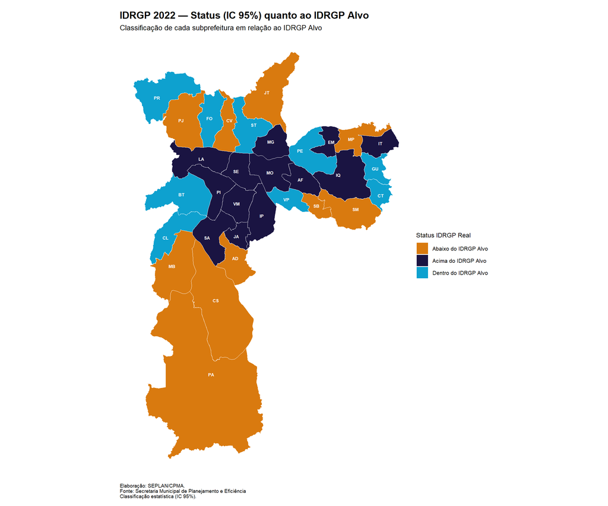

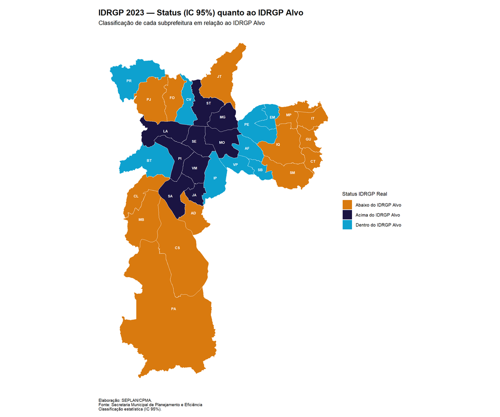

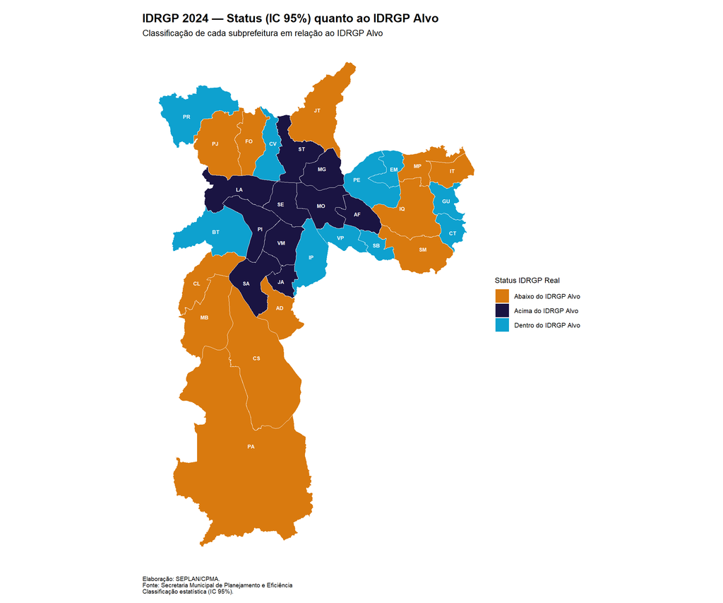

## 18.2. Mapa 2025 - status estatístico adotado

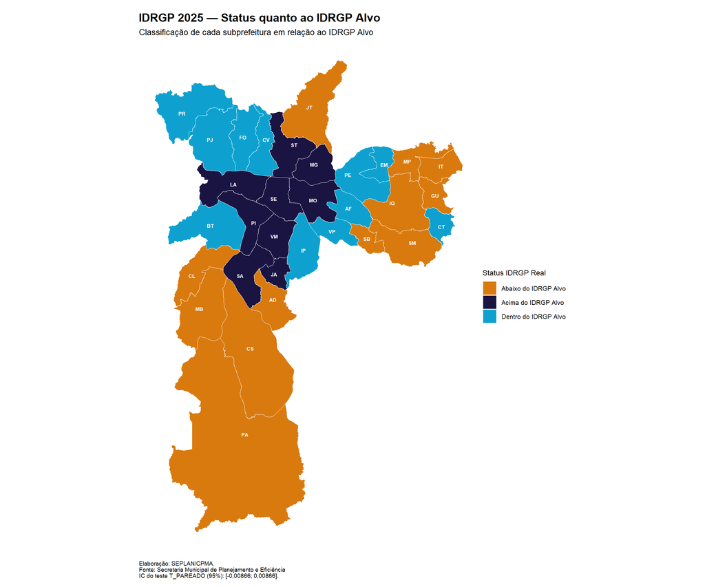

## 18.3. Mapa Agregado 2022–2025

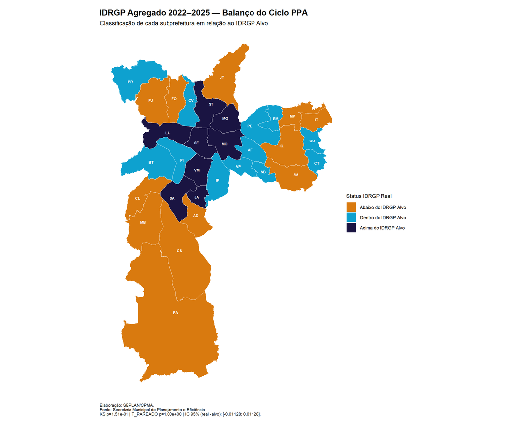

```
## ✅ 5 mapas gerados.
```

# 19. Geração de gráficos

Os gráficos complementam os mapas ao apresentar:

comparações entre previsto e executado; evolução temporal dos gastos; distribuição percentual e absoluta dos recursos.

Eles facilitam a leitura analítica e a identificação de tendências.

## 19.1. G1 — IDRGP 2025: Alvo vs. Real (%)

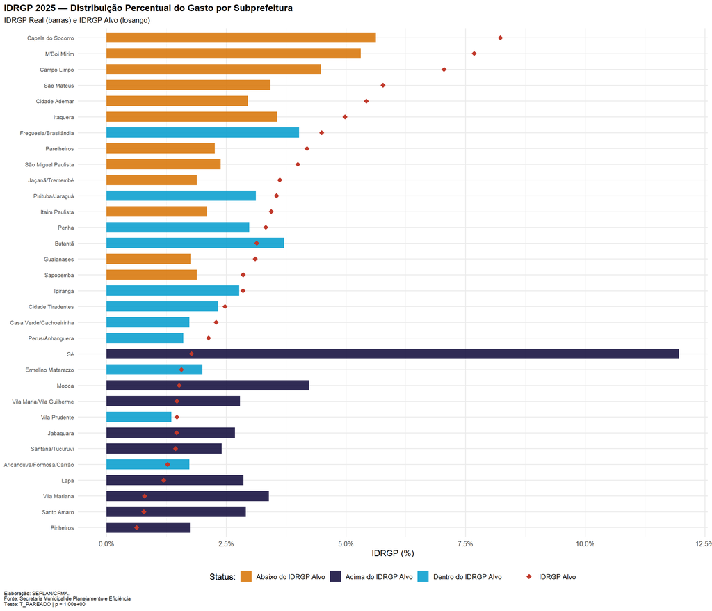

## 19.2. G2 — IDRGP Agregado 2022–2025 (%)

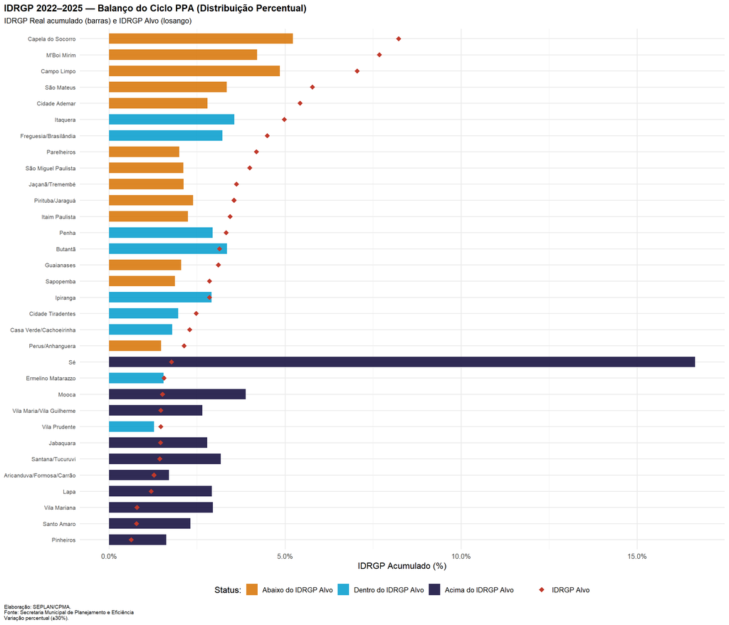

## 19.3. G3 — IDRGP 2025: Valores Absolutos (R$)

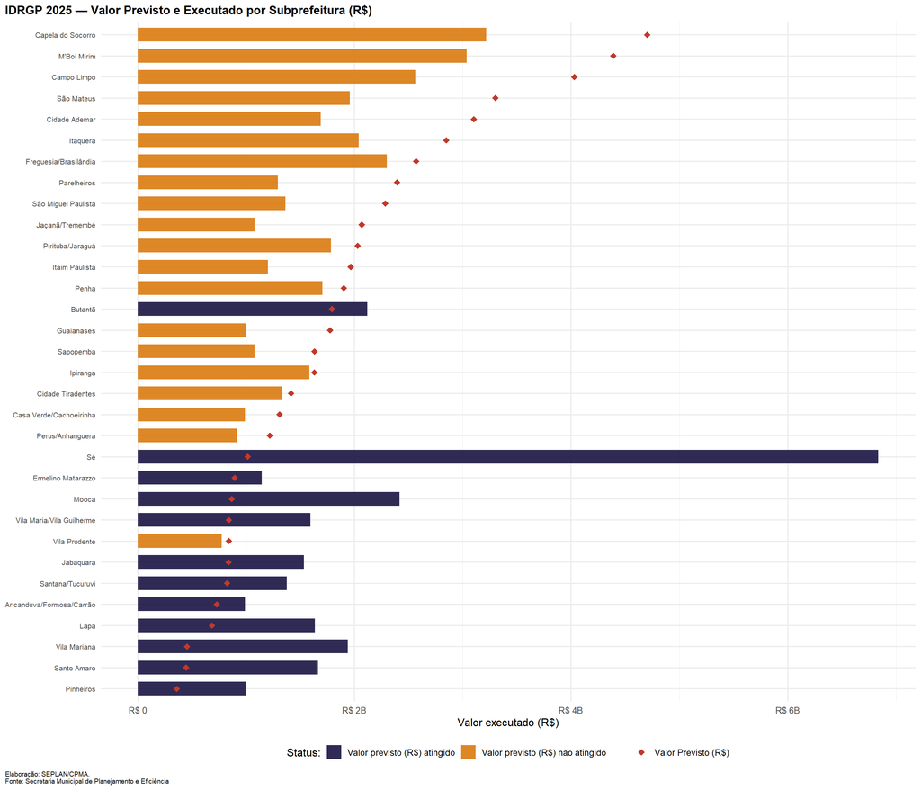

## 19.4. G4 — IDRGP 2022–2025: Série Histórica (R$)

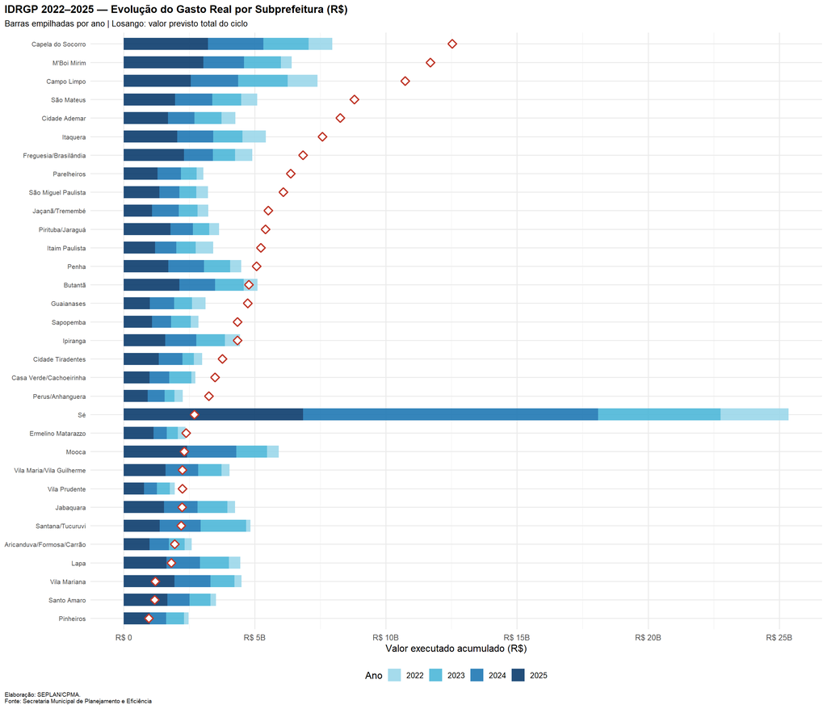

```
## ✅ 4 gráficos gerados.
```

### 20. Exportação de resultados

Este bloco garante que todos os produtos gerados (tabelas, mapas, gráficos e bases de dados) sejam salvos de forma estruturada.

Isso permite:

compartilhamento institucional; auditoria; reaproveitamento em outras análises.

```
## ✅ Arquivo detalhado gerado com 33 abas em resultados/df_anexo_2025.xlsx
```

## 20.1. Tabelas para 2022-2025

- Uma tabela para os 10 maiores proj/ativ e valor por sub
- Uma tabelea por sub com a distribuição dos maiores gastos por órgão

## 20.2. O segundo bloco aprofunda a análise ao observar não apenas “o que” é gasto, mas “quem” executa o gasto público no território. Inicialmente, é definida uma função que lê os arquivos anuais e identifica automaticamente as colunas relevantes (subprefeitura, órgão e valor), mesmo quando há variações nos nomes dessas colunas. Isso garante robustez ao processo e reduz a dependência de padronizações prévias nos arquivos de origem. Na sequência, os dados dos quatro anos são consolidados e agregados por subprefeitura e órgão executor, resultando no valor total executado por cada órgão em cada território. Para qualificar a análise, calcula-se também a participação percentual de cada órgão no total gasto da subprefeitura, permitindo compreender a estrutura relativa do gasto.Por fim, é produzida uma versão sintética da tabela, na qual órgãos com participação inferior a 4% são agrupados na categoria “Outros”. Essa decisão metodológica melhora a legibilidade dos resultados, destacando os principais atores institucionais responsáveis pela execução do orçamento em cada território.

# 20.3. Fazendo tabela para gráfico no anexo

## 20.4. Exportação de mapas e gráficos

```
## ✅ Mapas e gráficos exportados.
```

## 20.5. Exportação de dados em Excel

```
## ✅ Planilhas exportadas.
```

## 20.6. Exportação geoespacial

```
## [1] TRUE
```

```
## Writing layer `idrgp_2025' to data source
##   `resultados/idrgp_2025.gpkg' using driver `GPKG'
## Writing 32 features with 13 fields and geometry type Polygon.
```

```
## [1] TRUE
```

```
## Writing layer `idrgp_ciclo' to data source
##   `resultados/idrgp_ciclo_2022_2025.gpkg' using driver `GPKG'
## Writing 32 features with 13 fields and geometry type Polygon.
```

```
## Deleting layer `idrgp_2025_20260513' using driver `ESRI Shapefile'
## Writing layer `idrgp_2025_20260513' to data source
##   `resultados' using driver `ESRI Shapefile'
## Writing 32 features with 10 fields and geometry type Polygon.
```

```
## ✅ Arquivos geoespaciais exportados.
```

## 20.7. Mapas de localização (32 subprefeituras) + Tabela/Gráfico (ações regionalizadas)

```
## Gerando 32 mapas de localização...
```

```
## ✅ Mapas exportados em: resultados/mapas_subprefeituras
```

### 20.8 — Leitura e agregação por função orçamentária

```
## ✅ Dados para treemaps prontos: 32 subprefeituras, 21 funções.
```

### 20.9 — Geração e exportação dos treemaps por subprefeitura

```
## Gerando 32 treemaps...
```

```
## ✅ 32 treemaps exportados em: resultados/graficos_funcao_subprefeitura
```

## 21. Conclusão automatizada

Por fim, o relatório sintetiza os principais indicadores do ciclo analisado, incluindo o volume total de recursos e o método estatístico utilizado.

```
##   IDRGP 2022–2025 — Relatório concluído com sucesso.
```

```
##   Ciclo analisado:      2022 a 2025
```

```
##   Valor 2025:           R$ 57.170.300.140
```

```
##   Total ciclo:          R$ 152.268.439.221
```

```
##   Subprefeituras:       32
```

```
##   Método estatístico:   T_PAREADO
```

```
##   p-valor:              1,00e+00
```

```
##   IC 95%:              [ -0,00866 ; 0,00866 ]
```

```
##   Produtos em: resultados
```

```
##   Elaboração: SEPLAN/SIME/CPMA — Prefeitura de São Paulo, maio de 2026.
```